# Figure: Qualified responses and completed screenings over the duration of the DETECT pilot study (9-17-2015 to 10-26-2015)

Created: 2017-07-18 Updated: 2018-11-09

# Overview

What was the impact of the screening validation in the MedStar ePCR?

Initially, MedStar elected to implement the DETECT screening questions as an optional module in their ePCR. However, approximately 10 days after beginning the pilot study, they decided to add a validation rule to the ePCR. If the patient was 65 or older, and at their residence, the ePCR would validate that the DETECT screening tool was completed. If a medic selected “don’t know” for every screening item, this would satisfy the validation rule.

Below we merge the calls_by_date data with the screenings_by_date data, and investigate the impact of the validation rule on reporting.

```r
library(tidyverse)
library(bfuncs)
```

## Load data

Created in data_medstar_aps_merged_02_deidentify.Rmd

**These data have already been reduced to one row per pcr**

Can’t use the deidentified data because we need the “day” portion of the date.

```r
fig_responses_screenings_validation <- read_csv("/Volumes/Detect/fig_responses_screenings_validation.csv")
```

```r
about_data(fig_responses_screenings_validation) # 1,967 observations and 3 variables
```

```
[1] "1,967 observations and 3 variables"
```

## Calculate the number of pcrs by date

```r
calls_by_date <- fig_responses_screenings_validation %>%
  mutate(date = as.Date(date_entered)) %>%
  group_by(date) %>%
  summarise(pcrs = n()) %>%
  mutate(cum_pcrs = cumsum(pcrs)) %>%
  ungroup() %>%
  print()
```

| date | pcrs | cum_pcrs |
| --- | --- | --- |
| 2015-09-17 | 64 | 64 |
| 2015-09-18 | 52 | 116 |
| 2015-09-19 | 42 | 158 |
| 2015-09-20 | 51 | 209 |
| 2015-09-21 | 46 | 255 |
| 2015-09-22 | 54 | 309 |
| 2015-09-23 | 45 | 354 |
| 2015-09-24 | 57 | 411 |
| 2015-09-25 | 48 | 459 |
| 2015-09-26 | 42 | 501 |

[output cut: 30 more lines]

## Calculate the number of screeningsby date.

```r
screening_by_date <- fig_responses_screenings_validation %>%
  filter(detect_data == 1) %>%
  mutate(date = as.Date(date_entered)) %>%
  group_by(date) %>%
  summarise(screenings = n()) %>%
  mutate(cum_screening = cumsum(screenings)) %>%
  ungroup() %>%
  print()
```

| date | screenings | cum_screening |
| --- | --- | --- |
| 2015-09-17 | 3 | 3 |
| 2015-09-18 | 6 | 9 |
| 2015-09-19 | 3 | 12 |
| 2015-09-20 | 2 | 14 |
| 2015-09-21 | 1 | 15 |
| 2015-09-22 | 3 | 18 |
| 2015-09-23 | 1 | 19 |
| 2015-09-24 | 4 | 23 |
| 2015-09-26 | 1 | 24 |
| 2015-09-27 | 1 | 25 |

[output cut: 29 more lines]

## Merge the pcrs per day data with the screenings per day data.

```r
merged_by_date <- calls_by_date %>%
  left_join(screening_by_date, by = "date") %>%
  replace_na(list(screenings = 0, cum_screening = 0)) %>%
  mutate(validation = factor(if_else(date < "2015-09-28", "No", "Yes")))
```

It looks like the there’s a jump on September 28. According the Richard, this is where the validation rule was added.

Below we plot this data again, using different colors to indicate pre- and post-validation.

### Create a “long” version of merged by date

```r
merged_by_date_long <- merged_by_date %>%
  select(date, pcrs, screenings, validation) %>%
  gather(type, count, - date, - validation) %>%
  print()
```

| date | validation | type | count |
| --- | --- | --- | --- |
| 2015-09-17 | No | pcrs | 64 |
| 2015-09-18 | No | pcrs | 52 |
| 2015-09-19 | No | pcrs | 42 |
| 2015-09-20 | No | pcrs | 51 |
| 2015-09-21 | No | pcrs | 46 |
| 2015-09-22 | No | pcrs | 54 |
| 2015-09-23 | No | pcrs | 45 |
| 2015-09-24 | No | pcrs | 57 |
| 2015-09-25 | No | pcrs | 48 |
| 2015-09-26 | No | pcrs | 42 |

[output cut: 70 more lines]

## Plot

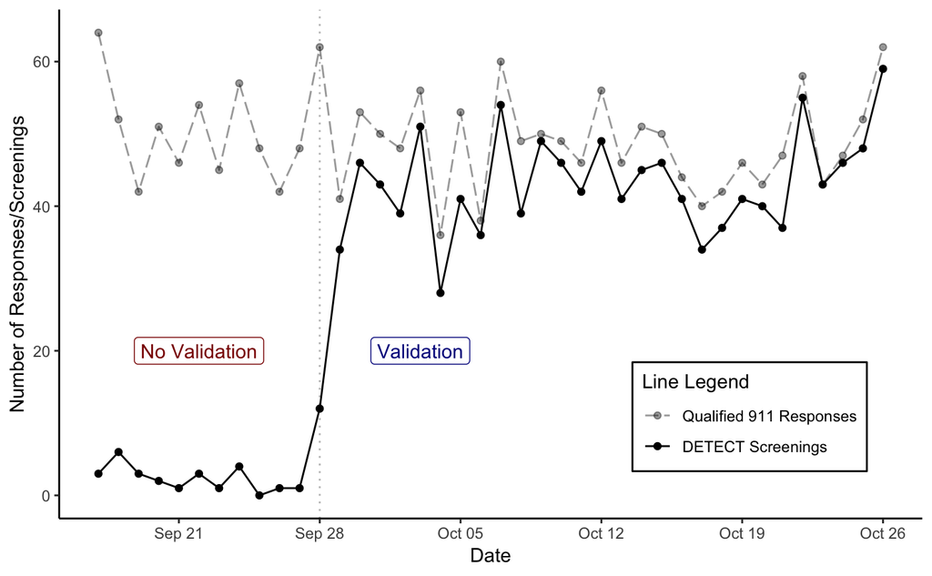

```r
fig_responses_screenings <- ggplot(merged_by_date_long, aes(x = date, y = count)) +
  geom_line(aes(group = type, linetype = type, alpha = type)) +
  geom_point(aes(group = type, alpha = type)) +
  annotate(
    "label",
    x = as.Date("2015-09-22"),
    y = 20,
    label = "No Validation",
    color = "dark red"
  ) +
  annotate(
    "label",
    x = as.Date("2015-10-03"),
    y = 20,
    label = "Validation",
    color = "dark blue"
  ) +
  geom_vline(aes(xintercept = as.numeric(as.Date("2015-09-28"))), alpha = 0.3, linetype = 3) +
  scale_x_date("Date", date_minor_breaks = "1 day") +
  scale_y_continuous("Number of Responses/Screenings") +
  scale_linetype_manual("Line Legend", values = c("longdash", "solid"),
                        labels = c("Qualified 911 Responses", "DETECT Screenings")) +
  scale_alpha_discrete("Line Legend", range = c(0.4, 1.0),
                       labels = c("Qualified 911 Responses", "DETECT Screenings")) +
  theme_classic() +
  theme(
    legend.position = c(0.8, 0.2),
    legend.background = element_rect(color = "black")
  )
fig_responses_screenings
```

## Save as a jpg

```r
ggsave("../images/fig_responses_screenings_validation_line_graph.jpeg",
       fig_responses_screenings, device = "jpeg", width = 7, height = 4)
```

## Clean up

```r
rm(list = ls())
```

top